# Novel_data_science_project

Sarah, Max, and Jennie

2024-04-22

```r
colorize <- function(x, color) {
  if (knitr::is_latex_output()) {
    sprintf("\\textcolor{%s}{%s}", color, x)
  } else if (knitr::is_html_output()) {
    sprintf("<span style='color: %s;'>%s</span>", color,
      x)
  } else x
}
```

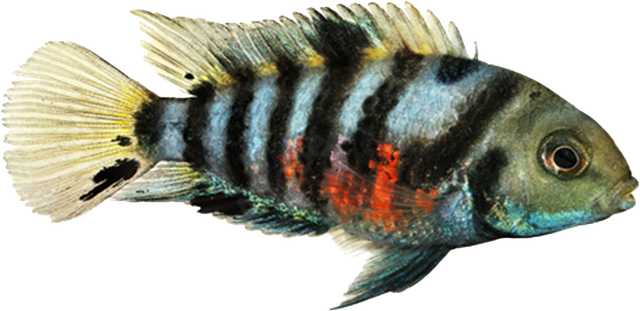

A female convict cichlid.

```r
knitr::include_graphics("https://i.ibb.co/DL0NPSJ/2024-04-26-cichlid.png")
```

## Overview

Our package aims to create functions focused on model selection. Here we have created an ANOVA function, Kruskal-Wallis function, Post-Hoc Tukey test function, Mann-Whitney U function, and functions that allow for forward and backwards model selection. To present these functions and their use, we will describe their purpose and use an example dataset to showcase their practicality for data.

## Preliminaries

Install these packages: {skimr}, {tidyverse}, {broom}, {MASS}, {AICcmodavg}, and {MuMIn}.

## Introduction

An individual’s internal state, or “social state”, can influence how they respond to different social cues and contexts. Examples of social states include reproductive state, parental state, status in a hierarchy, and forming a pairbond. These social states can make an individual more aggressive, submissive, or affiliative in different contexts. Convict cichlids (*A. nigrofasciata*) form pairbonds and exhibit bi-parental care (2 different social states). We can use these fish to study how social state influences behavioral response (aggressive vs. affiliative) and if this influence differs between males and females.

## Experimental setup

Convict cichlid pairs were apportioned into four different treatments:

**Rival (pairbond-aggressive):** A second “rival” conspecific male is introduced to the pairbonded male and female. This elicits an aggressive response towards the rival.

**Bond (pairbond-affiliative):** A pairbonded male and female are separated for 30min. When they are re-introduced to each other they exhibit affiliative behaviors.

**Predator (parental-aggressive):** A wolf cichlid (convict egg predator) is introduced to the nest of a male and female with fry. This elicits an aggressive response as the convict cichlids defend their nest.

**Retrieval (parental-affiliative):** The fry are removed from the nest and placed in a different part of the tank. The male and female then retrieve their young and bring them back to the nest.

Male and females behaviors were scored for 10 minutes during each treatment. A total of 44 pairs were tested.

## Data analysis

A principle component analysis was run on the raw behavior data first. The eigenvalues for PC1 (Response) and PC2 (Social State) were extracted for each individual. This is the dataset included in the Rpackage and that we will use for this vignette.

For the descriptive statistic, we will calculate the means and standard deviations for each treatment group by sex. We will run an ANOVA to look for significant differences and then use a posthoc Tukey test to determine where the significant differences are. We will test the residuals using a qqplot and shapiro-wilks test for normality. If the data are non parametric, we will instead use a Kruskal-Wallis and Mann-Whitney U to find significant differences in how each social state predicts behavioral responses.

### Novel Data Set Example!

1. First you will load in all the relavent packages and read in the dataset

```r
#Load in libraries
library(skimr)
library(tidyverse)
library(broom)
library(MASS)
library(MuMIn)
library(AICcmodavg)
#Load in data
f<-"https://raw.githubusercontent.com/SarahArtemis/Novel_Data_Science/main/ConvictCichlid_PC1%262_eigenvalues.csv"
d<-read.csv(f, header = TRUE)
skim(d) # could also use head(d)
```

Data summary

| Name | d |
| --- | --- |
| Number of rows | 88 |
| Number of columns | 9 |
| _______________________ |  |
| Column type frequency: |  |
| character | 6 |
| numeric | 3 |
| ________________________ |  |
| Group variables | None |

**Variable type: character**

| skim_variable | n_missing | complete_rate | min | max | empty | n_unique | whitespace |
| --- | --- | --- | --- | --- | --- | --- | --- |
| Tank | 0 | 1 | 10 | 13 | 0 | 44 | 0 |
| Treatment | 0 | 1 | 4 | 8 | 0 | 4 | 0 |
| State | 0 | 1 | 4 | 8 | 0 | 2 | 0 |
| Response | 0 | 1 | 10 | 11 | 0 | 2 | 0 |
| Sex | 0 | 1 | 1 | 1 | 0 | 2 | 0 |
| Fish.ID | 0 | 1 | 12 | 15 | 0 | 88 | 0 |

**Variable type: numeric**

| skim_variable | n_missing | complete_rate | mean | sd | p0 | p25 | p50 | p75 | p100 | hist |
| --- | --- | --- | --- | --- | --- | --- | --- | --- | --- | --- |
| row | 0 | 1 | 46.3 | 26.56 | 1.00 | 23.75 | 46.00 | 69.25 | 91.00 | ▇▇▇▇▇ |
| PC_1_value | 0 | 1 | 0.0 | 2.12 | -2.76 | -1.76 | -0.92 | 1.85 | 5.09 | ▇▃▂▃▁ |
| PC_2_value | 0 | 1 | 0.0 | 1.36 | -1.96 | -0.96 | -0.33 | 0.87 | 5.36 | ▇▆▃▁▁ |

### Descriptive statistics

2. Next, using the summarise() function, create a separate tibble that holds the mean, median, and SD of PC1 and PC2 eigenvalues grouped by Treatment and Sex

```r
avg<-d%>%
  group_by(Treatment, Sex)%>%
  summarise(meanPC1=mean(PC_1_value), sdPC1=sd(PC_1_value), medianPC1=median(PC_1_value), meanPC2=mean(PC_2_value), sdPC2=sd(PC_2_value), medianPC2=median(PC_2_value))
head(avg)
```

```
## # A tibble: 6 × 8
## # Groups:   Treatment [3]
##   Treatment Sex   meanPC1 sdPC1 medianPC1 meanPC2 sdPC2 medianPC2
##   <chr>     <chr>   <dbl> <dbl>     <dbl>   <dbl> <dbl>     <dbl>
## 1 bond      F       -1.38 0.663     -1.34  -1.07  0.558    -1.25
## 2 bond      M       -1.28 0.592     -1.41  -0.543 0.458    -0.447
## 3 predator  F        2.43 1.13       1.93   2.13  1.94      1.78
## 4 predator  M        2.36 0.861      2.13  -0.523 1.07     -0.574
## 5 retrieve  F       -2.12 0.307     -2.21   1.41  0.496     1.24
## 6 retrieve  M       -1.83 0.334     -1.76   0.603 0.586     0.454
```

### Visualize data

3. Next using our boxplot function, we create boxplots of PC1 and PC2 eigenvalues categorically separated by treatment type and sex

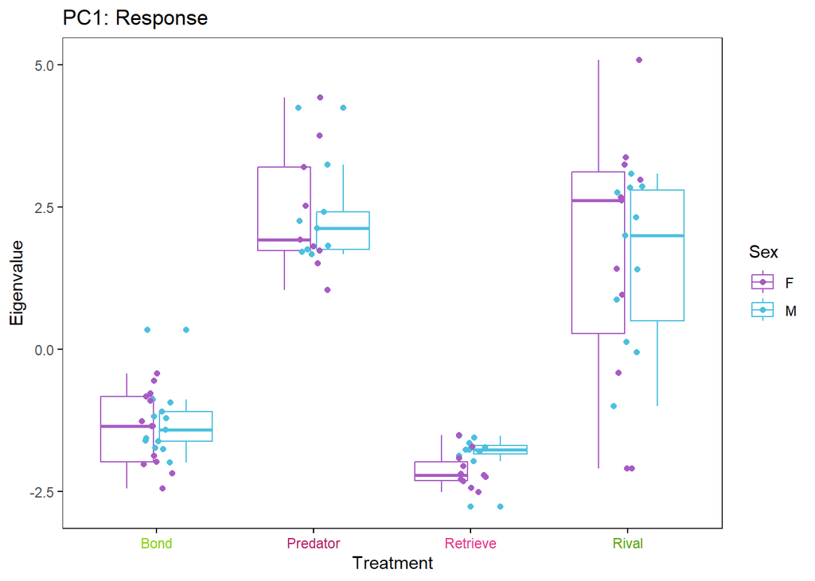

```r
#PC1 - Affiliative vs Aggressive (Response)
a<-ggplot(d, aes(x=Treatment, y=(PC_1_value), col=Sex)) +
  geom_boxplot() +
  geom_jitter(width = 0.10) +
  ggtitle("PC1: Response") +
  xlab("Treatment") +
  ylab("Eigenvalue") +
  theme_bw() +
  theme(axis.text.x = element_text(color = c("#89CE00", "#B51963", "#E6308A", "#5BA300")),
        axis.ticks = element_line(color = "black"),
        panel.grid.major = element_blank(),
        panel.grid.minor = element_blank()) +
  scale_color_manual(values = c("#A75BC4", "#4CC0DE")) +
  scale_fill_manual(values = c("#BF68E1", "#57DDFF")) +
  scale_x_discrete(labels = c("Bond", "Predator", "Retrieve", "Rival"))
a
```

Using this general descriptive method, we can tell that in PC1: response, bond and retrieve (the two affiliative treatments) appear to cluster together, while predator and rival (the two aggressive treatments) appear to cluster together. Males and females appear to have no statistically significant differences in response based on their treatment groups. However, treatment groups appear to be distinct from one another.

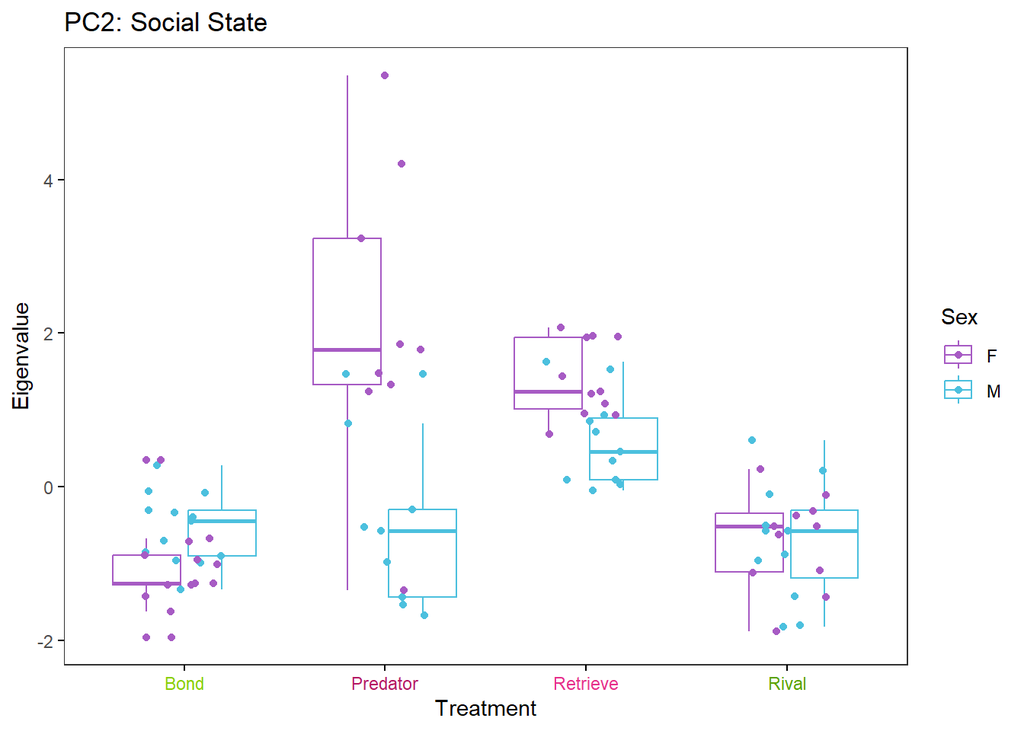

```r
#PC2 - Bond vs Parental (State)
b<-ggplot(d, aes(x=Treatment, y=PC_2_value, col=Sex)) +
  geom_boxplot() +
  geom_jitter(width = 0.2) +
  ggtitle("PC2: Social State") +
  xlab("Treatment") +
  ylab("Eigenvalue") +
  theme_bw() +
  theme(axis.text.x = element_text(color = c("#89CE00", "#B51963", "#E6308A", "#5BA300")),
        axis.ticks = element_line(color = "black"),
        panel.grid.major = element_blank(),
        panel.grid.minor = element_blank()) +
  scale_color_manual(values = c("#A75BC4", "#4CC0DE")) +
  scale_fill_manual(values = c("#BF68E1", "#57DDFF")) +
  scale_x_discrete(labels = c("Bond", "Predator", "Retrieve", "Rival"))
b
```

In this boxplot it appears that males do not differ between treatments along PC2, but females in predator and retrieve treatments differ from females in bond and rival treatments along PC2.

### Test for significant differences with ANOVA

To test the validity of these claims, we must use an ANOVA test. an ANOVA allows you to test the statistical difference between several categorical variables. In this case we will be using an anova to determine whether treatment group, social state, response, sex, or the interactions between any of these variables is statistically different from each other in terms of PC1 and PC2 eigenvalues. However, ANOVAs make an assumption of normality, and require roughly equal sample variances. Thus, we must check the residuals of our ANOVA models and test for normality.

First we use our ANOVA function to create an anova with all the explanatory variables and PC1 response variable

```r
#PC1 - Affiliative vs Aggressive (Response)
m1 <- aov(data = d, PC_1_value ~ Treatment + State + Response + Sex + Treatment:Sex + State:Sex + Response:Sex)
tidy(m1)
```

```
## # A tibble: 4 × 6
##   term             df   sumsq meansq statistic   p.value
##   <chr>         <dbl>   <dbl>  <dbl>     <dbl>     <dbl>
## 1 Treatment         3 291.    97.0      76.7    1.82e-23
## 2 Sex               1   0.127  0.127     0.101  7.52e- 1
## 3 Treatment:Sex     3   0.454  0.151     0.120  9.48e- 1
## 4 Residuals        80 101.     1.26     NA     NA
```

Next we must use the qqnorm() function and shapiro-wilks test function to determine if our ANOVA assumptions are correct.

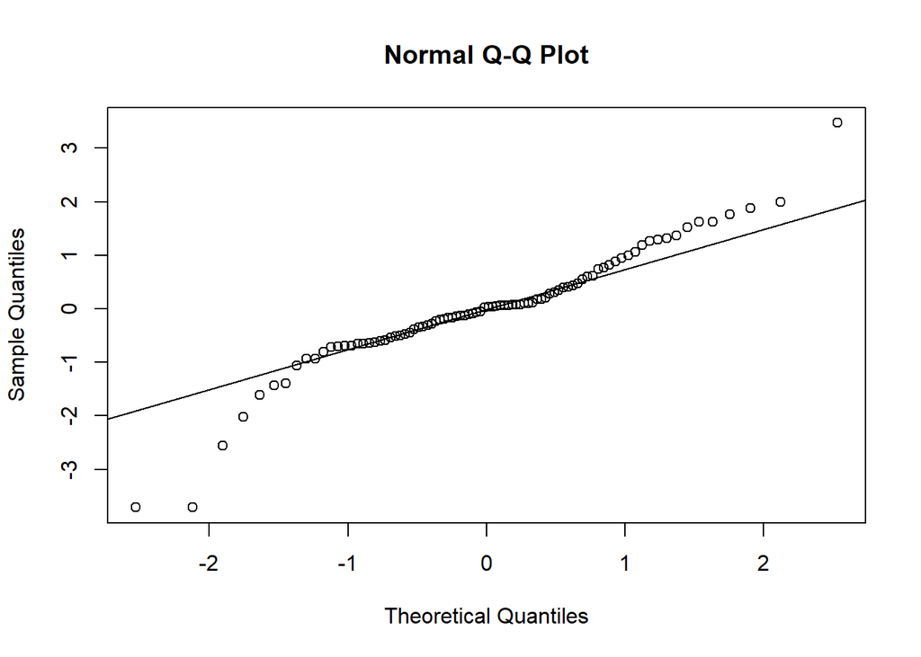

```r
#Q plot of residuals
qqnorm(m1$residuals)
qqline(m1$residuals)
```

The QQplot does not perfectly match the QQline end to end, suggesting that residuals do not fall in line with our assumption of normal distribution

To confirm, using the shapiro.test() function, we run a shapiro-wilks test

```r
#Test for normality
(s <- shapiro.test(m1$residuals))
```

```
##
##  Shapiro-Wilk normality test
##
## data:  m1$residuals
## W = 0.93337, p-value = 0.0002142
```

The results of the shapiro test provide a P-value <0.05, suggesting that our data distributes differently from that of a normal distribution

We can attempt to resolve this by log-transforming the data and retesting for normality.

```r
#Rerun with log transform
#PC1 - Affiliative vs Aggressive (Response)
m1_l <- aov(data = d, log(PC_1_value) ~ Treatment + State + Response + Sex + Treatment:Sex + State:Sex + Response:Sex)
tidy(m1_l)
```

```
## # A tibble: 4 × 6
##   term             df  sumsq meansq statistic p.value
##   <chr>         <dbl>  <dbl>  <dbl>     <dbl>   <dbl>
## 1 Treatment         2  3.34   1.67       4.10  0.0263
## 2 Sex               1  0.443  0.443      1.09  0.305
## 3 Treatment:Sex     1  0.537  0.537      1.32  0.260
## 4 Residuals        31 12.6    0.408     NA    NA
```

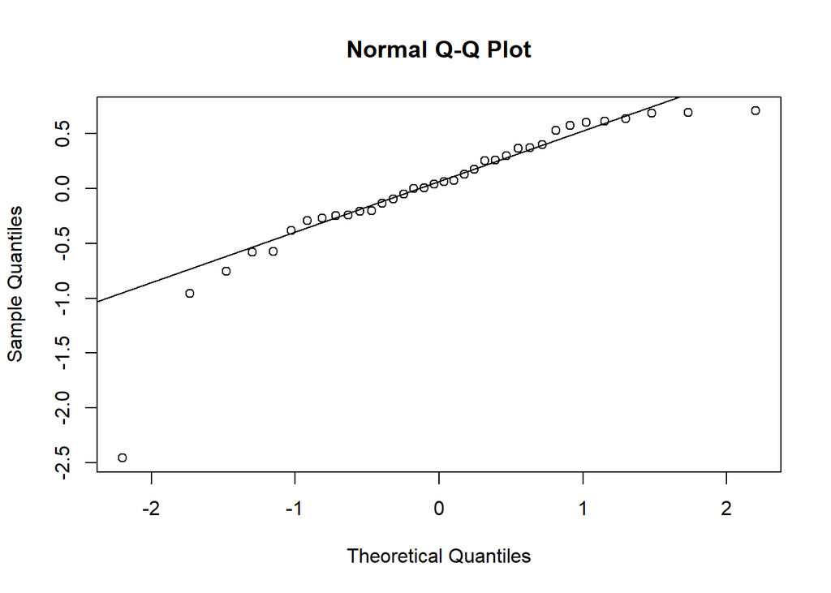

```r
#Q plot of residuals
qqnorm(m1_l$residuals)
qqline(m1_l$residuals)
```

```r
#Test for normality
(s <- shapiro.test(m1_l$residuals))
```

```
##
##  Shapiro-Wilk normality test
##
## data:  m1_l$residuals
## W = 0.84023, p-value = 0.0001143
```

Yet again, the results of the shapiro test provide a P-value <0.05, suggesting that our data distributes differently from that of a normal distribution. Thus, we must use a non-parametric version of an ANOVA, which does not hold the same assumption of normal distributions: The Kruskal-Wallis test.

We next run a kruskal-Wallis test of PC1 eigenvalues against treatment and sex

```r
#Use non-parametric Kruskal-Wallis test
#Treatment
(kw1_t <- kruskal.test(data = d, PC_1_value ~ Treatment))
```

```
##
##  Kruskal-Wallis rank sum test
##
## data:  PC_1_value by Treatment
## Kruskal-Wallis chi-squared = 59.251, df = 3, p-value = 8.499e-13
```

```r
#Sex
(kw1_t <- kruskal.test(data = d, PC_1_value ~ Sex))
```

```
##
##  Kruskal-Wallis rank sum test
##
## data:  PC_1_value by Sex
## Kruskal-Wallis chi-squared = 0.65528, df = 1, p-value = 0.4182
```

Next, we run an ANOVA of the same explanatory variables against PC2 with interactions and test residuals for normality

```r
#PC2 - Bond vs Parental (State)
m2 <- aov(data = d, PC_2_value ~ Treatment + State + Response + Sex + Treatment:Sex + State:Sex + Response:Sex)
tidy(m2)
```

```
## # A tibble: 4 × 6
##   term             df sumsq meansq statistic   p.value
##   <chr>         <dbl> <dbl>  <dbl>     <dbl>     <dbl>
## 1 Treatment         3 61.7  20.6       26.9   4.03e-12
## 2 Sex               1  7.62  7.62       9.95  2.27e- 3
## 3 Treatment:Sex     3 29.4   9.78      12.8   6.66e- 7
## 4 Residuals        80 61.3   0.766     NA    NA
```

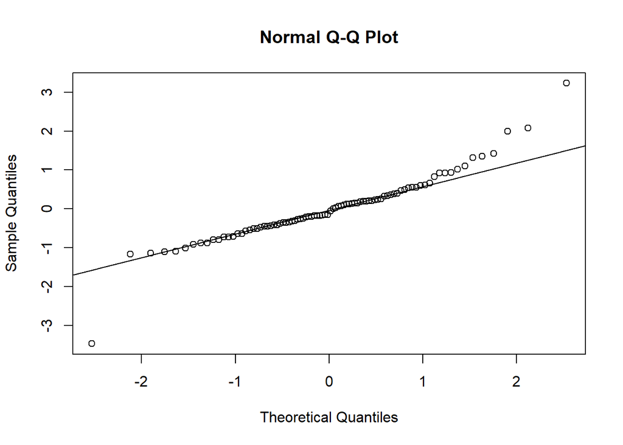

```r
#Q plot of residuals
qqnorm(m2$residuals)
qqline(m2$residuals)
```

```r
(s <- shapiro.test(m2$residuals))
```

```
##
##  Shapiro-Wilk normality test
##
## data:  m2$residuals
## W = 0.91931, p-value = 4.014e-05
```

According to the shapiro-wilks test, the distribution of residuals is not normal, thus we attempt to solve this using a log transformation

```r
#Rerun with log transform
#PC2 - Bond vs Parental (State)
m2_l <- aov(data = d, log(PC_2_value) ~ Treatment + State + Response + Sex + Treatment:Sex + State:Sex + Response:Sex)
tidy(m2)
```

```
## # A tibble: 4 × 6
##   term             df sumsq meansq statistic   p.value
##   <chr>         <dbl> <dbl>  <dbl>     <dbl>     <dbl>
## 1 Treatment         3 61.7  20.6       26.9   4.03e-12
## 2 Sex               1  7.62  7.62       9.95  2.27e- 3
## 3 Treatment:Sex     3 29.4   9.78      12.8   6.66e- 7
## 4 Residuals        80 61.3   0.766     NA    NA
```

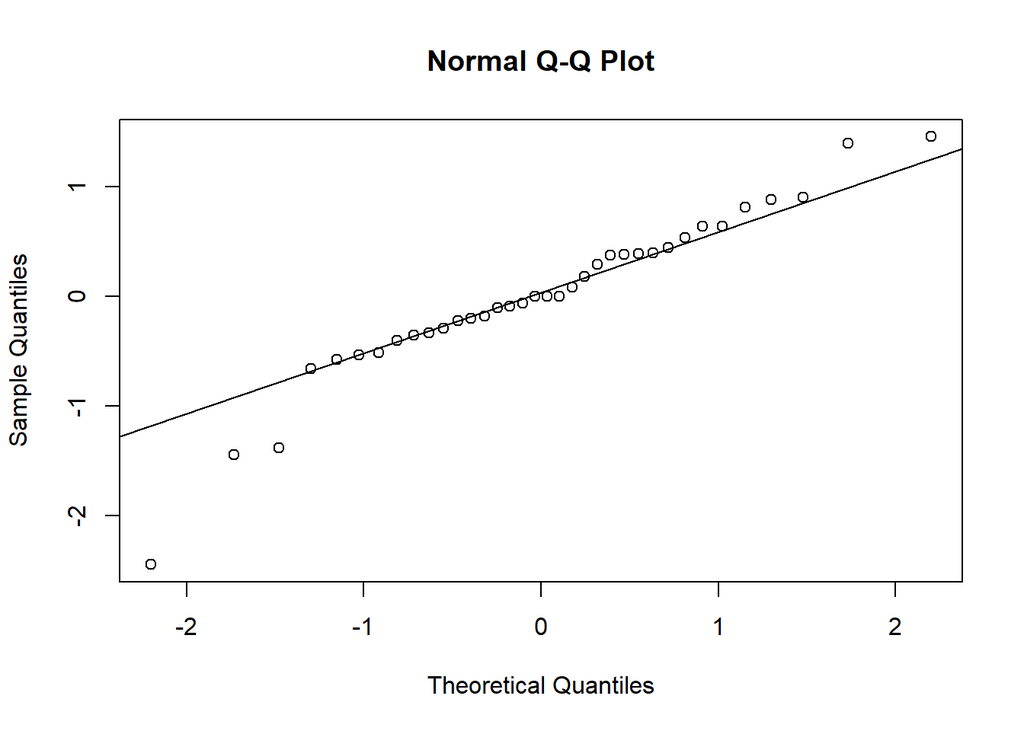

```r
#Q plot of residuals
qqnorm(m2_l$residuals)
qqline(m2_l$residuals)
```

```r
(s <- shapiro.test(m2_l$residuals))
```

```
##
##  Shapiro-Wilk normality test
##
## data:  m2_l$residuals
## W = 0.94243, p-value = 0.06047
```

Given that the shapiro test for m2 residuals produced a p value > 0.05, we can conclude that this relationship (marginally) achieves normality of residuals. Thus, an ANOVA is an appropriate test for observing the relationships between PC2 and the categorical variables.

### Post-hoc test

```r
#PC1 - Affiliative vs Aggressive (Response)
(Tukey_1 <- TukeyHSD(m1, which = "Treatment", ordered = TRUE, conf.level = 0.95))
```

```
##   Tukey multiple comparisons of means
##     95% family-wise confidence level
##     factor levels have been ordered
##
## Fit: aov(formula = PC_1_value ~ Treatment + State + Response + Sex + Treatment:Sex + State:Sex + Response:Sex, data = d)
##
## $Treatment
##                        diff        lwr      upr     p adj
## bond-retrieve     0.6464731 -0.2081255 1.501072 0.2023108
## rival-retrieve    3.5656090  2.6761146 4.455103 0.0000000
## predator-retrieve 4.3728149  3.4352055 5.310424 0.0000000
## rival-bond        2.9191359  2.0645373 3.773734 0.0000000
## predator-bond     3.7263418  2.8217702 4.630913 0.0000000
## predator-rival    0.8072059 -0.1304035 1.744815 0.1165414
```

```r
(MWU_1<-pairwise.wilcox.test(d$PC_1_value, d$Treatment, p.adjust.method = "bonferroni"))
```

```
##
##  Pairwise comparisons using Wilcoxon rank sum exact test
##
## data:  d$PC_1_value and d$Treatment
##
##          bond    predator retrieve
## predator 1.2e-11 -        -
## retrieve 0.00054 1.1e-10  -
## rival    2.2e-06 1.00000  1.0e-07
##
## P value adjustment method: bonferroni
```

```r
#PC2 - Bond vs Parental (State)
(Tukey_2 <- TukeyHSD(m2_l, which = "Treatment:Sex", ordered = TRUE, conf.level = 0.95))
```

```
##   Tukey multiple comparisons of means
##     95% family-wise confidence level
##     factor levels have been ordered
##
## Fit: aov(formula = log(PC_2_value) ~ Treatment + State + Response + Sex + Treatment:Sex + State:Sex + Response:Sex, data = d)
##
## $`Treatment:Sex`
##                               diff         lwr      upr     p adj
## bond:M-rival:F        0.1797009692 -3.74714956 4.106552 0.9999999
## rival:M-rival:F       0.4176353696 -2.98311695 3.818388 0.9998996
## bond:F-rival:F        0.4179596290 -3.50889090 4.344810 0.9999618
## retrieve:M-rival:F    0.4881522952 -2.42407800 3.400383 0.9992161
## predator:M-rival:F    1.5541283204 -1.84662400 4.954881 0.8038672
## retrieve:F-rival:F    1.7363261336 -1.16384519 4.636497 0.5256932
## predator:F-rival:F    2.2529200082 -0.69221789 5.198058 0.2356844
## rival:M-bond:M        0.2379344004 -3.16281792 3.638687 0.9999978
## bond:F-bond:M         0.2382586598 -3.68859187 4.165109 0.9999992
## retrieve:M-bond:M     0.3084513260 -2.60377897 3.220682 0.9999630
## predator:M-bond:M     1.3744273512 -2.02632497 4.775180 0.8828862
## retrieve:F-bond:M     1.5566251644 -1.34354616 4.456796 0.6531725
## predator:F-bond:M     2.0732190390 -0.87191886 5.018357 0.3273730
## bond:F-rival:M        0.0003242594 -3.40042806 3.401077 1.0000000
## retrieve:M-rival:M    0.0705169256 -2.08030769 2.221342 1.0000000
## predator:M-rival:M    1.1364929508 -1.64020969 3.913196 0.8761408
## retrieve:F-rival:M    1.3186907640 -0.81577754 3.453159 0.4869716
## predator:F-rival:M    1.8352846386 -0.35989154 4.030461 0.1539401
## retrieve:M-bond:F     0.0701926662 -2.84203763 2.982423 1.0000000
## predator:M-bond:F     1.1361686914 -2.26458363 4.536921 0.9531361
## retrieve:F-bond:F     1.3183665046 -1.58180482 4.218538 0.8079151
## predator:F-bond:F     1.8349603792 -1.11017752 4.780098 0.4764983
## predator:M-retrieve:M 1.0659760252 -1.08484859 3.216801 0.7343969
## retrieve:F-retrieve:M 1.2481738383  0.03494513 2.461403 0.0403653
## predator:F-retrieve:M 1.7647677130  0.44766200 3.081873 0.0032801
## retrieve:F-predator:M 0.1821978132 -1.95227049 2.316666 0.9999915
## predator:F-predator:M 0.6987916878 -1.49638450 2.893968 0.9635758
## predator:F-retrieve:F 0.5165938746 -0.77362930 1.806817 0.8876861
```